# **`Problem Statement: Concrete Strength Prediction`**

### **`Objective:`**

To predict the concrete strength using the data available in file "concrete.csv". Apply feature engineering and model tuning to obtain a score above 85%.

### **`Resources Available:`**

The data for this project is available in file:

https://archive.ics.uci.edu/ml/machine-learning-databases/concrete/compressive

### **`Attribute Information:`**

Given are the variable name, variable type, the measurement unit, and a brief description. The concrete compressive strength is the regression problem. The order of this listing corresponds to the order of numerals along the rows of the database.

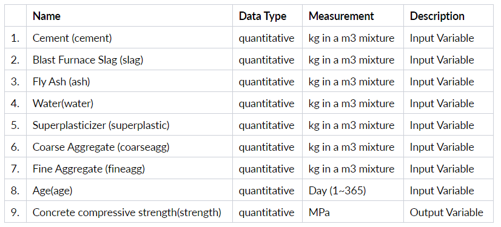

## **`Steps and Tasks:`**

### **`Deliverable – 1: Exploratory Data Quality Report Reflecting the Following (12 Marks)`**

1. Data types and description of the independent attributes which should include (name, range of values observed, central values (mean and median), standard deviation and quartiles, analysis of the body of distributions/tails. **(2 Marks)**
2. Missing values analysis, Outlier detection, Duplicates check, Comment about if the zero values mean the null value here. **(4 Marks)**
3. Using various plots, write the insights/observations about it. **(6 Marks)**

### **`Deliverable – 2: Bi-Variate Analysis (8 Marks)`**

Bi-Variate Analysis Between The Predictor Variables And Also Between The Predictor Variables And Target Column. Comment On Your Findings In Terms Of Their Relationship And Degree Of Relation If Any. Visualize The Analysis Using Boxplots And Pair Plots, Histograms, Or Density Curves And Write The Insights/Business Understanding Of The Same. **(8 Marks)**

### **`Deliverable – 3: Feature Engineering techniques (8 Marks)`**

1. Identify opportunities (if any) to extract new features from existing features, drop a feature(if required) Hint: Feature Extraction, for example, consider a dataset with two features length and breadth. From this, we can extract a new feature Area which would be length * breadth. **(3 Marks)**.
2. Get the data model ready and do a train test split.
3. Decide on the complexity of the model, should it be a simple linear model in terms of parameters or would a quadratic or higher degree. **(5 Marks)**

### **`Deliverable – 4: Creating the Model and Tuning It: (15 Marks)`**

1. Algorithms that you think will be suitable for this project.
2. Use Kfold Cross-Validation to evaluate model performance. Use appropriate metrics and make a DataFrame to compare models w.r.t their metrics. (at least 3 algorithms, one bagging and one boosting based algorithms have to be there and try to achieve 90% accuracy on testing set). **(7 Marks)**
3. Techniques employed to squeeze that extra performance out of the model without making it overfit. Use Grid Search or Random Search on any of the two models used above. Make a DataFrame to compare models after hyperparameter tuning and their metrics as above. **(8 Marks)**

### **`Deliverable – 5:`**

Write the significance of the R2 score from the business perspective. Explain the effect of an increase/decrease in the R2 score on the business model. **(4 Marks)**

### **`Deliverable – 6:`**

Write down the inference about the data analysis and write the recommendations which can be beneficial to the business based on the whole analysis. Also, write the reason for your recommendation. **(8 Marks)**

### **`Deliverable – 7:`**

The marks for the score will be according to the following: testing score **90 -95 (5 marks), 85 - 90 (4 marks), 80 - 85( 3 marks), <80 (2 marks)**

# `Index:`

- **Deliverable – 1 (Exploratory Data Quality Report) – (12):**
- **Deliverable – 2 (Bi-Variate Analysis) – (8)**
- **Deliverable – 3 (Feature Engineering techniques) – (8)**
- **Deliverable – 4: Creating the Model and Tuning It – (15)**
- **Deliverable – 5: Significance of the R2 Score – (4)**
- **Deliverable – 6: Inference And Recommendations Based on Data Analysis – (8)**
- **Deliverable – 7: Achieve a Testing Score of 90 to 95 – (5)**

# **`Deliverable – 1 (Exploratory Data Quality Report)`**

Back to Index

```python
#import libraries
import numpy as np
import pandas as pd
import matplotlib.pyplot as plt
import seaborn as sns
%matplotlib inline
from sklearn.impute import SimpleImputer
from sklearn.model_selection import train_test_split
from sklearn.tree import DecisionTreeClassifier
from sklearn import tree
from sklearn import metrics
from os import system
from sklearn.linear_model import LinearRegression
from IPython.display import Image
from sklearn.metrics import recall_score, precision_score, f1_score, roc_auc_score,accuracy_score

from sklearn.model_selection import KFold
from sklearn.model_selection import cross_val_score
```

```python
#Read Data
pdata  = pd.read_csv('concrete.csv')
pdata.head(10)
```

|  | cement | slag | ash | water | superplastic | coarseagg | fineagg | age | strength |
| --- | --- | --- | --- | --- | --- | --- | --- | --- | --- |
| 0 | 141.3 | 212.0 | 0.0 | 203.5 | 0.0 | 971.8 | 748.5 | 28 | 29.89 |
| 1 | 168.9 | 42.2 | 124.3 | 158.3 | 10.8 | 1080.8 | 796.2 | 14 | 23.51 |
| 2 | 250.0 | 0.0 | 95.7 | 187.4 | 5.5 | 956.9 | 861.2 | 28 | 29.22 |
| 3 | 266.0 | 114.0 | 0.0 | 228.0 | 0.0 | 932.0 | 670.0 | 28 | 45.85 |
| 4 | 154.8 | 183.4 | 0.0 | 193.3 | 9.1 | 1047.4 | 696.7 | 28 | 18.29 |
| 5 | 255.0 | 0.0 | 0.0 | 192.0 | 0.0 | 889.8 | 945.0 | 90 | 21.86 |
| 6 | 166.8 | 250.2 | 0.0 | 203.5 | 0.0 | 975.6 | 692.6 | 7 | 15.75 |
| 7 | 251.4 | 0.0 | 118.3 | 188.5 | 6.4 | 1028.4 | 757.7 | 56 | 36.64 |
| 8 | 296.0 | 0.0 | 0.0 | 192.0 | 0.0 | 1085.0 | 765.0 | 28 | 21.65 |
| 9 | 155.0 | 184.0 | 143.0 | 194.0 | 9.0 | 880.0 | 699.0 | 28 | 28.99 |

### **`Observation:`**

No nulls observed. There are some zeros in columns slag, ash, and superplastic. Check further, how many zeros are present in each of these columns and also if they can be considered as missing values.

## **`Univariate Analysis:`**

Back to Index

Data types and description of the independent attributes which should include (name, range of values observed, central values (mean and median), standard deviation and quartiles, analysis of the body of distributions/tails. (2 Marks) Missing values analysis, Outlier detection, Duplicates check, Comment about if the zero values mean the null value here. (4 Marks) Using various plots, write the insights/observations about it. (6 Marks)

```python
#Stastical Analysis
print(pdata.shape)
```

```
(1030, 9)
```

```python
pdata.info()
```

```
<class 'pandas.core.frame.DataFrame'>
RangeIndex: 1030 entries, 0 to 1029
Data columns (total 9 columns):
 #   Column        Non-Null Count  Dtype
---  ------        --------------  -----
 0   cement        1030 non-null   float64
 1   slag          1030 non-null   float64
 2   ash           1030 non-null   float64
 3   water         1030 non-null   float64
 4   superplastic  1030 non-null   float64
 5   coarseagg     1030 non-null   float64
 6   fineagg       1030 non-null   float64
 7   age           1030 non-null   int64
 8   strength      1030 non-null   float64
dtypes: float64(8), int64(1)
memory usage: 72.5 KB
```

```python
pdata.describe().T
```

|  | count | mean | std | min | 25% | 50% | 75% | max |
| --- | --- | --- | --- | --- | --- | --- | --- | --- |
| cement | 1030.0 | 281.167864 | 104.506364 | 102.00 | 192.375 | 272.900 | 350.000 | 540.0 |
| slag | 1030.0 | 73.895825 | 86.279342 | 0.00 | 0.000 | 22.000 | 142.950 | 359.4 |
| ash | 1030.0 | 54.188350 | 63.997004 | 0.00 | 0.000 | 0.000 | 118.300 | 200.1 |
| water | 1030.0 | 181.567282 | 21.354219 | 121.80 | 164.900 | 185.000 | 192.000 | 247.0 |
| superplastic | 1030.0 | 6.204660 | 5.973841 | 0.00 | 0.000 | 6.400 | 10.200 | 32.2 |
| coarseagg | 1030.0 | 972.918932 | 77.753954 | 801.00 | 932.000 | 968.000 | 1029.400 | 1145.0 |
| fineagg | 1030.0 | 773.580485 | 80.175980 | 594.00 | 730.950 | 779.500 | 824.000 | 992.6 |
| age | 1030.0 | 45.662136 | 63.169912 | 1.00 | 7.000 | 28.000 | 56.000 | 365.0 |
| strength | 1030.0 | 35.817961 | 16.705742 | 2.33 | 23.710 | 34.445 | 46.135 | 82.6 |

### **`Observations:`**

Back to Index

1. There are 9 columns and 1030 rows in the dataset.
2. All columns, except age, are float. Datatype conversion won't be required.
3. All columns have same unit, except for target column and age. No unit conversion required.
4. More than 50% rows contain value 0 for ash. More than 25% rows contain value 0 for slag and superplastic.
5. As explained in data definition, age ranges between 1 and 365. It's an integer. More than 75% values are less than or equal to 56. Therefore, there might be a few outliers in this column.
6. For columns cement, water, superplastic, coarseagg, fineagg, and strength, there is no significant difference between mean and median. Therefore, from primary analysis, it looks as if these columns are fairly distributed. For slag, ash, and age, there is a notable difference between the mean and median values.
7. Looks like there are outliers in some columns. Corresponding analysis (distribution + outliers) is performed as follows

```python
#Step1: Find out how many nulls each column has:

print("Column Names and number of nulls they contains is as follows:")
print(pdata.isnull().sum()) # Number of nulls in each column of the dataframe
#pdata.isnull().values.any() # This is another way to check if there are any null values in data set
```

```
Column Names and number of nulls they contains is as follows:
cement          0
slag            0
ash             0
water           0
superplastic    0
coarseagg       0
fineagg         0
age             0
strength        0
dtype: int64
```

```python
#Step2: Find out how many zeros are present in data.

print(pdata[:][pdata[:] == 0].count()) # Number of zeros in a column
```

```
cement            0
slag            471
ash             566
water             0
superplastic    379
coarseagg         0
fineagg           0
age               0
strength          0
dtype: int64
```

### **`Observations:`**

Back to Index

1. slag and ash are some sort of impurities in concrete mixture and can ideally be reduced to zero. Their absence in concrete may indicate an improved quality of concrete.
2. superplastic is an additive, and some builders may choose not to add it in the concrete.

Based on above assumptions, presence of zeros in these three fields is considered normal and we will not make any imputations to zeros in these columns.

```python
#Step3: Find if any negative values are present in data:

print(pdata[:][pdata[:] < 0].count()) # Number of negatives in a column
```

```
cement          0
slag            0
ash             0
water           0
superplastic    0
coarseagg       0
fineagg         0
age             0
strength        0
dtype: int64
```

```python
#Step4: Find number of unique values in each column. Analyse outcome for categorical variables.

pdata.nunique() # Number of unique values in a column
```

```
cement          278
slag            185
ash             156
water           195
superplastic    111
coarseagg       284
fineagg         302
age              14
strength        845
dtype: int64
```

### **`Observations:`**

Back to Index

1. There are duplicate values in all columns. This looks normal.
2. No nulls and negatives observed.
3. Columns slag, ash, and superplastic have more than 25% zeros. It may be worth checking with a domain expert to understand if these columns can contain a zero in them. Since this option is not available, check if these zeros are outliers in data. If they are, then only they will be treated. Otherwise, they will be considered as normal.
4. Since age has small number of unique values, it might be worth performing frequency analysis.

```python
# Let's find if there are any duplicate rows in the dataset
pdata1 = pdata.duplicated().sum
```

```python
# It could be observed in
duplicateRowsDF = pdata[pdata.duplicated(['cement', 'slag', 'ash', 'water', 'superplastic', 'coarseagg', 'fineagg','age', 'strength'])]

duplicateRowsDF1 = duplicateRowsDF.sort_values(by=['cement', 'slag', 'ash', 'water', 'superplastic', 'coarseagg', 'fineagg','age', 'strength'])
```

```python
# Important Imputation: Remove duplicate rows before doing further analysis / imputation:
pdata.drop_duplicates(subset=['cement', 'slag', 'ash', 'water', 'superplastic', 'coarseagg', 'fineagg', 'age', 'strength'], keep='last')
```

|  | cement | slag | ash | water | superplastic | coarseagg | fineagg | age | strength |
| --- | --- | --- | --- | --- | --- | --- | --- | --- | --- |
| 0 | 141.3 | 212.0 | 0.0 | 203.5 | 0.0 | 971.8 | 748.5 | 28 | 29.89 |
| 1 | 168.9 | 42.2 | 124.3 | 158.3 | 10.8 | 1080.8 | 796.2 | 14 | 23.51 |
| 2 | 250.0 | 0.0 | 95.7 | 187.4 | 5.5 | 956.9 | 861.2 | 28 | 29.22 |
| 3 | 266.0 | 114.0 | 0.0 | 228.0 | 0.0 | 932.0 | 670.0 | 28 | 45.85 |
| 4 | 154.8 | 183.4 | 0.0 | 193.3 | 9.1 | 1047.4 | 696.7 | 28 | 18.29 |
| ... | ... | ... | ... | ... | ... | ... | ... | ... | ... |
| 1025 | 135.0 | 0.0 | 166.0 | 180.0 | 10.0 | 961.0 | 805.0 | 28 | 13.29 |
| 1026 | 531.3 | 0.0 | 0.0 | 141.8 | 28.2 | 852.1 | 893.7 | 3 | 41.30 |
| 1027 | 276.4 | 116.0 | 90.3 | 179.6 | 8.9 | 870.1 | 768.3 | 28 | 44.28 |
| 1028 | 342.0 | 38.0 | 0.0 | 228.0 | 0.0 | 932.0 | 670.0 | 270 | 55.06 |
| 1029 | 540.0 | 0.0 | 0.0 | 173.0 | 0.0 | 1125.0 | 613.0 | 7 | 52.61 |

1005 rows × 9 columns

```python
#Step5: Part1 Frequency analysis for categorical variables.
#Since age column has only 14 unique values it might be useful to do some frequency analysis

# value counts gives us how many times does the value
print(pdata['age'].value_counts(normalize=True))
print('')
```

```
28     0.412621
3      0.130097
7      0.122330
56     0.088350
14     0.060194
90     0.052427
100    0.050485
180    0.025243
91     0.021359
365    0.013592
270    0.012621
360    0.005825
120    0.002913
1      0.001942
Name: age, dtype: float64
```

### **`Observations: (for column age)`**

Back to Index

1. More than 75% rows contain a value less than or equal to 75.
2. Around 90% values are less than 100.
3. Seems there are outliers.
4. Consider to form categories of age. **Note**: Above action (categorization of age) was not carried out considering that age is strongly correlated to the target variable. Any contamination of data might impact the model severely. Also, categorization was not performed since the problem under focus is regression, and not classification.

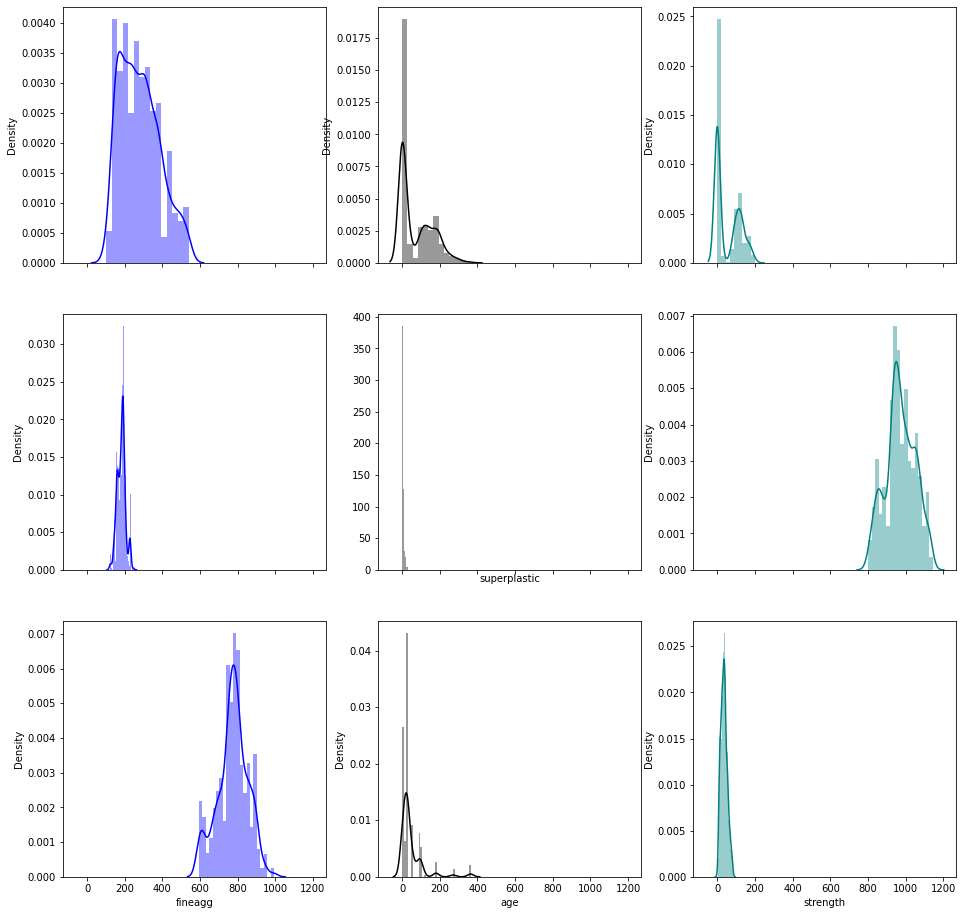

```python
#Step6: Distribution Analysis

import warnings
warnings.filterwarnings("ignore")

f, axes = plt.subplots(3, 3, figsize=(16, 16), sharex=True)
sns.distplot( pdata["cement"] , color="blue", ax=axes[0, 0])
sns.distplot( pdata["slag"] , color="black", ax=axes[0, 1])
sns.distplot( pdata["ash"] , color="teal", ax=axes[0, 2])

sns.distplot( pdata["water"] , color="blue", ax=axes[1, 0])
sns.distplot( pdata["superplastic"] , color="black", kde=False, ax=axes[1, 1])
sns.distplot( pdata["coarseagg"] , color="teal", ax=axes[1, 2])

sns.distplot( pdata["fineagg"] , color="blue", ax=axes[2, 0])
sns.distplot( pdata["age"] , color="black", ax=axes[2, 1])
sns.distplot( pdata["strength"] , color="teal", ax=axes[2, 2])
```

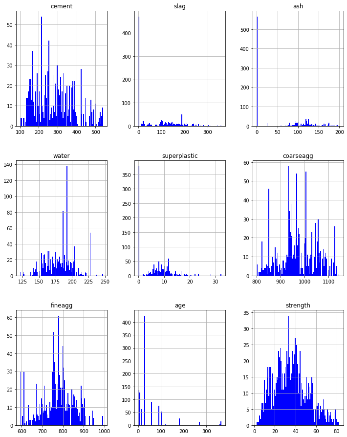

```python
columns = list(pdata)[:]
pdata[columns].hist(stacked=False, bins=100, figsize=(12,55), layout=(10,3), color='Blue');
```

### **`Observations:`**

Back to Index

1. These columns seem fairly distributed: cement, water, coarseagg, fineagg, and strength.
2. Distribution for slag and ash is similar. We can further check if they are highly correlated. Also, it might be worth checking if these columns have any significant contribution towards the target variable. If not, they can be dropped.
3. Age is right skewed, upper bound outliers can be seen. However, as per the definition, the range of values in the column is between 1 and 365.
4. For "superplastic" and "strength", distribution is concentrated around a very small range of values.
5. The above histgram strengthen the observations for distplot analysis.

```python
#Step6: Outlier Analysis: Method used: IQR

percentile_25 = {}
percentile_75 = {}
iqr = {}
lower_bound = {}
upper_bound = {}

for i in pdata:
  percentile_25[i] = np.percentile(pdata[i],25)
  percentile_75[i] = np.percentile(pdata[i],75)
  iqr[i] = percentile_75[i] - percentile_25[i]
  lower_bound[i] = percentile_25[i] - (1.5 * iqr[i])
  upper_bound[i] = percentile_75[i] + (1.5 * iqr[i])


print(percentile_25)
print(percentile_75)
print(iqr)
print(lower_bound)
print(upper_bound)
print("\n")
```

```
{'cement': 192.375, 'slag': 0.0, 'ash': 0.0, 'water': 164.9, 'superplastic': 0.0, 'coarseagg': 932.0, 'fineagg': 730.9499999999999, 'age': 7.0, 'strength': 23.709999999999997}
{'cement': 350.0, 'slag': 142.95, 'ash': 118.3, 'water': 192.0, 'superplastic': 10.2, 'coarseagg': 1029.4, 'fineagg': 824.0, 'age': 56.0, 'strength': 46.135000000000005}
{'cement': 157.625, 'slag': 142.95, 'ash': 118.3, 'water': 27.099999999999994, 'superplastic': 10.2, 'coarseagg': 97.40000000000009, 'fineagg': 93.05000000000007, 'age': 49.0, 'strength': 22.425000000000008}
{'cement': -44.0625, 'slag': -214.42499999999998, 'ash': -177.45, 'water': 124.25000000000001, 'superplastic': -15.299999999999999, 'coarseagg': 785.8999999999999, 'fineagg': 591.3749999999998, 'age': -66.5, 'strength': -9.927500000000013}
{'cement': 586.4375, 'slag': 357.375, 'ash': 295.75, 'water': 232.64999999999998, 'superplastic': 25.5, 'coarseagg': 1175.5000000000002, 'fineagg': 963.575, 'age': 129.5, 'strength': 79.77250000000001}
```

```python
for i in pdata:
    print("Count of lower bound outliers for column "+ i + ": " + str(pdata[i][pdata[i] < lower_bound[i]].count()))
    print("Count of upper bound outliers for column "+ i + ": " + str(pdata[i][pdata[i] > upper_bound[i]].count()))
```

```
Count of lower bound outliers for column cement: 0
Count of upper bound outliers for column cement: 0
Count of lower bound outliers for column slag: 0
Count of upper bound outliers for column slag: 2
Count of lower bound outliers for column ash: 0
Count of upper bound outliers for column ash: 0
Count of lower bound outliers for column water: 5
Count of upper bound outliers for column water: 4
Count of lower bound outliers for column superplastic: 0
Count of upper bound outliers for column superplastic: 10
Count of lower bound outliers for column coarseagg: 0
Count of upper bound outliers for column coarseagg: 0
Count of lower bound outliers for column fineagg: 0
Count of upper bound outliers for column fineagg: 5
Count of lower bound outliers for column age: 0
Count of upper bound outliers for column age: 59
Count of lower bound outliers for column strength: 0
Count of upper bound outliers for column strength: 4
```

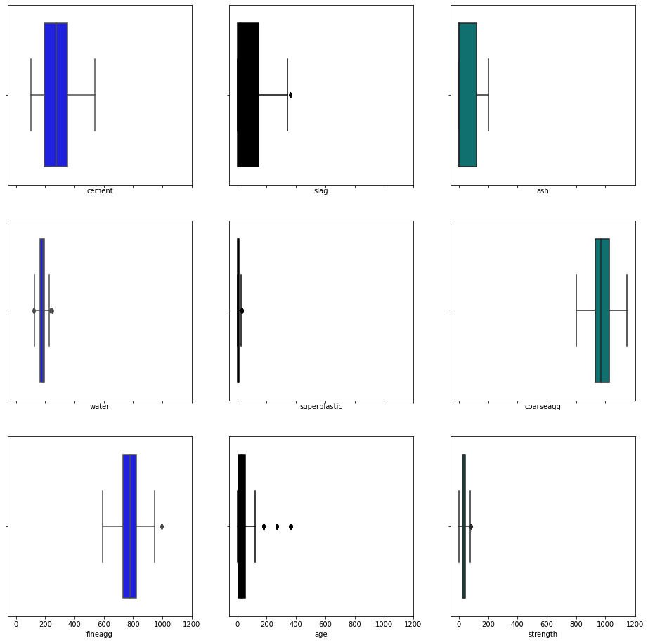

```python
#Step7: BoxPlot Analysis

import warnings
warnings.filterwarnings("ignore")

f, axes = plt.subplots(3, 3, figsize=(16, 16), sharex=True)
sns.boxplot( pdata["cement"] , color="blue", ax=axes[0, 0])
sns.boxplot( pdata["slag"] , color="black", ax=axes[0, 1])
sns.boxplot( pdata["ash"] , color="teal", ax=axes[0, 2])

sns.boxplot( pdata["water"] , color="blue", ax=axes[1, 0])
sns.boxplot( pdata["superplastic"] , color="black",  ax=axes[1, 1])
sns.boxplot( pdata["coarseagg"] , color="teal", ax=axes[1, 2])

sns.boxplot( pdata["fineagg"] , color="blue", ax=axes[2, 0])
sns.boxplot( pdata["age"] , color="black", ax=axes[2, 1])
sns.boxplot( pdata["strength"] , color="teal", ax=axes[2, 2])
```

### **`Observations:`**

Back to Index

# **`Deliverable – 2: Bi-Variate Analysis:`**

Back to Index

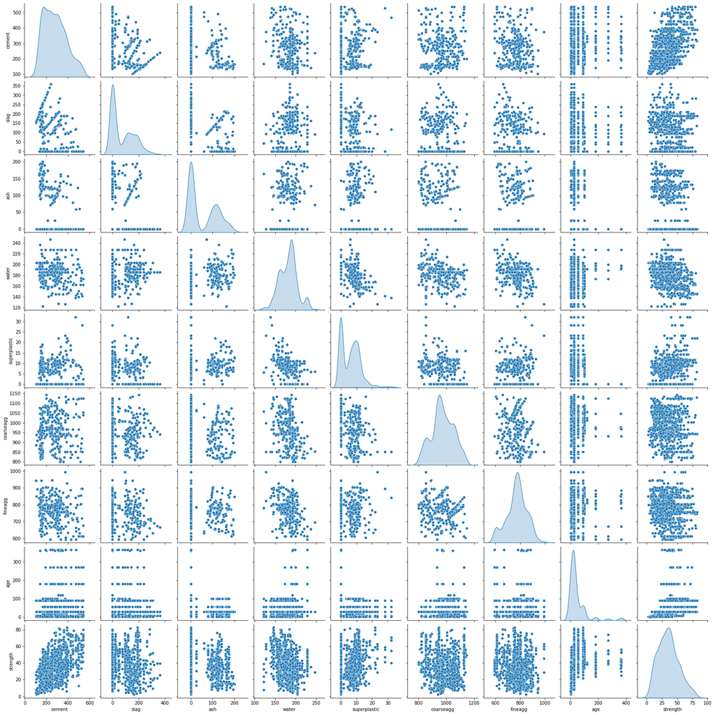

```python
#Step1: Pairplot analysis

sns.pairplot(pdata,diag_kind='kde')
```

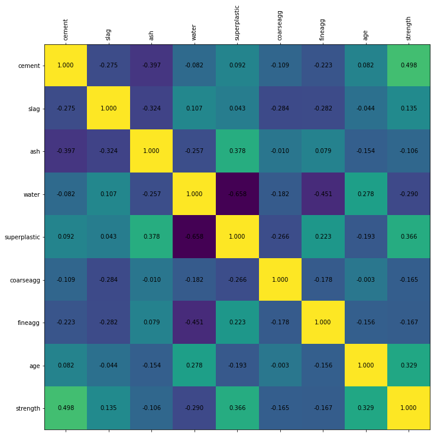

```python
# Plotting correlation to analyze how target variable is correlated with other variables
def plot_corr(df, size=12):
    corr = df.corr()
    fig, ax = plt.subplots(figsize=(size, size))
    ax.matshow(corr)
    plt.xticks(range(len(corr.columns)), corr.columns, rotation='vertical')
    plt.yticks(range(len(corr.columns)), corr.columns)
    for (i, j), z in np.ndenumerate(corr):
        ax.text(j, i, '{:0.3f}'.format(z), ha='center', va='center')

plot_corr(pdata)
```

```python
pdata.corr().round(3)
```

|  | cement | slag | ash | water | superplastic | coarseagg | fineagg | age | strength |
| --- | --- | --- | --- | --- | --- | --- | --- | --- | --- |
| cement | 1.000 | -0.275 | -0.397 | -0.082 | 0.092 | -0.109 | -0.223 | 0.082 | 0.498 |
| slag | -0.275 | 1.000 | -0.324 | 0.107 | 0.043 | -0.284 | -0.282 | -0.044 | 0.135 |
| ash | -0.397 | -0.324 | 1.000 | -0.257 | 0.378 | -0.010 | 0.079 | -0.154 | -0.106 |
| water | -0.082 | 0.107 | -0.257 | 1.000 | -0.658 | -0.182 | -0.451 | 0.278 | -0.290 |
| superplastic | 0.092 | 0.043 | 0.378 | -0.658 | 1.000 | -0.266 | 0.223 | -0.193 | 0.366 |
| coarseagg | -0.109 | -0.284 | -0.010 | -0.182 | -0.266 | 1.000 | -0.178 | -0.003 | -0.165 |
| fineagg | -0.223 | -0.282 | 0.079 | -0.451 | 0.223 | -0.178 | 1.000 | -0.156 | -0.167 |
| age | 0.082 | -0.044 | -0.154 | 0.278 | -0.193 | -0.003 | -0.156 | 1.000 | 0.329 |
| strength | 0.498 | 0.135 | -0.106 | -0.290 | 0.366 | -0.165 | -0.167 | 0.329 | 1.000 |

### **`Observations:`**

Back to Index

1. The diagonal axis in pairplot is similar to the distplot that we have already plotted and analyzed.
2. In a few cases, the independent variables also have some correlation. e.g. Water has strong correlations (+ve or -ve) with superplastic, fineagg, age etc. Superplastic has correlation with ash and fineagg etc.
3. Strength (Target) has strongest positive correlationship with cement, followed by superplastic and age.
4. Also, it has strongest -ve correlation with water as expected.
5. **Coarseagg and fineagg** have similar correlation with strength. As observed previously, their distribution plots are also similar. So, these two fields can **either be combined (added) to create a new field called ConcreteAggregate or one of these fields can be removed before model building**. The decision can be taken after checking the significance of these variables on model.
6. Ash and slag have some correlation with strength.
7. Considering 0.1 (+ve or -ve) as a fair correlation, we can see that all independent variables affect the strength.
8. Overall, cement, superplastic, water, and age contribute most significantly towards the strength.

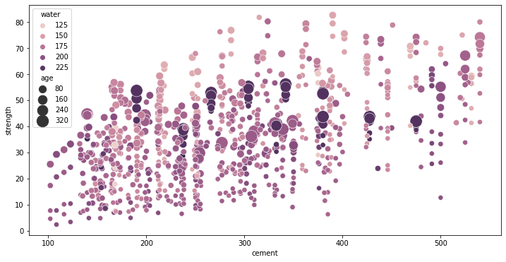

```python
fig, ax = plt.subplots(figsize=(12, 6))

sns.scatterplot(data=pdata, y="strength", x="cement", hue="water",ax=ax,size="age",sizes=(50,300));
```

### **`Observations:`**

Back to Index

The observations we can make from this plot,

1. Strength increases as the amount of cement increases, as the dots move up when we move towards right on the x-axis.
2. Strength increases with age (as the size of dots represents the age), this not the case always but can be up to an extent. Mixtures with less age requires more cement for higher strength, as the smaller dots are moving up when we move towards right on the x-axis.
3. The older the cement is the more water it requires, can be confirmed by observing the colour of the dots. Larger dots with dark colour indicate high age and more water.
4. Concrete strength increases when less water is used in preparing it since the dots on the lower side (y-axis) are darker and the dots on higher-end (y-axis) are brighter.

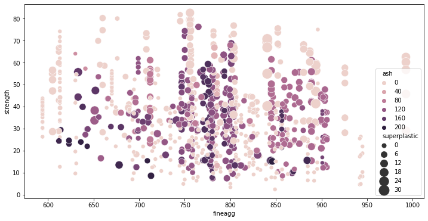

```python
fig, ax = plt.subplots(figsize=(12, 6))

sns.scatterplot(data=pdata, y="strength", x="fineagg", hue="ash",ax=ax,size="superplastic",sizes=(50,300));
```

### **`Observations:`**

Back to Index

1. Strength decreases ash increases, as darker dots are concentrated in the region representing low compressive strength.
2. Strength increases with Superplasticizer since larger the dot the higher they are in the plot.

# **`Deliverable – 3: Feature Engineering techniques (8 Marks) And Deliverable – 4: Creating the Model and Tuning It: (15 Marks):`**

Back to Index

## **`Approach:`**

Back to Index

```python
from sklearn.impute import SimpleImputer

n = pdata[pdata['water'] <= lower_bound["water"]].water.unique()
print(n)

#Step2: Replace every lower outlier with mean
for i in n:
    #print(i)
    rep_0 = SimpleImputer(missing_values=i, strategy="mean")
    cols=['water']
    imputer = rep_0.fit(pdata[cols])
    pdata[cols] = imputer.transform(pdata[cols])


n = pdata[pdata['water'] >= upper_bound["water"]].water.unique()
print(n)

#Step2: Replace every lower upper with mean
for i in n:
    #print(i)
    rep_0 = SimpleImputer(missing_values=i, strategy="mean")
    cols=['water']
    imputer = rep_0.fit(pdata[cols])
    pdata[cols] = imputer.transform(pdata[cols])

n = pdata[pdata['slag'] >= upper_bound["slag"]].slag.unique()
print(n)

#Step2: Replace every lower upper with mean
for i in n:
    #print(i)
    rep_0 = SimpleImputer(missing_values=i, strategy="mean")
    cols=['slag']
    imputer = rep_0.fit(pdata[cols])
    pdata[cols] = imputer.transform(pdata[cols])

n = pdata[pdata['superplastic'] >= upper_bound["superplastic"]].superplastic.unique()
print(n)

#Step2: Replace every lower upper with mean
for i in n:
    #print(i)
    rep_0 = SimpleImputer(missing_values=i, strategy="mean")
    cols=['superplastic']
    imputer = rep_0.fit(pdata[cols])
    pdata[cols] = imputer.transform(pdata[cols])


n = pdata[pdata['fineagg'] >= upper_bound["fineagg"]].fineagg.unique()
print(n)

#Step2: Replace every lower upper with mean
for i in n:
    #print(i)
    rep_0 = SimpleImputer(missing_values=i, strategy="mean")
    cols=['fineagg']
    imputer = rep_0.fit(pdata[cols])
    pdata[cols] = imputer.transform(pdata[cols])


n = pdata[pdata['age'] >= upper_bound["age"]].age.unique()
print(n)

#Step2: Replace every lower upper with mean
for i in n:
    #print(i)
    rep_0 = SimpleImputer(missing_values=i, strategy="mean")
    cols=['age']
    imputer = rep_0.fit(pdata[cols])
    pdata[cols] = imputer.transform(pdata[cols])

"""
n = pdata[pdata['strength'] >= upper_bound["strength"]].strength.unique()
print(n)

#Step2: Replace every lower upper with mean
for i in n:
    #print(i)
    rep_0 = SimpleImputer(missing_values=i, strategy="mean")
    cols=['strength']
    imputer = rep_0.fit(pdata[cols])
    pdata[cols] = imputer.transform(pdata[cols])
"""
```

```
[121.8]
[247.  246.9 237.  236.7]
[359.4]
[28.2 32.2]
[992.6]
[180 365 270 360]
```

[output not shown]

```python
for i in pdata:
    print("Count of lower bound outliers for column "+ i + ": " + str(pdata[i][pdata[i] < lower_bound[i]].count()))
    print("Count of upper bound outliers for column "+ i + ": " + str(pdata[i][pdata[i] > upper_bound[i]].count()))
```

```
Count of lower bound outliers for column cement: 0
Count of upper bound outliers for column cement: 0
Count of lower bound outliers for column slag: 0
Count of upper bound outliers for column slag: 0
Count of lower bound outliers for column ash: 0
Count of upper bound outliers for column ash: 0
Count of lower bound outliers for column water: 0
Count of upper bound outliers for column water: 0
Count of lower bound outliers for column superplastic: 0
Count of upper bound outliers for column superplastic: 0
Count of lower bound outliers for column coarseagg: 0
Count of upper bound outliers for column coarseagg: 0
Count of lower bound outliers for column fineagg: 0
Count of upper bound outliers for column fineagg: 0
Count of lower bound outliers for column age: 0
Count of upper bound outliers for column age: 0
Count of lower bound outliers for column strength: 0
Count of upper bound outliers for column strength: 4
```

```python
#Splitting the data into independent and dependent attributes

#independent and dependent variables
X = pdata.drop('strength', axis=1)
y = pdata['strength']
```

```python
#Split data
x_train, x_test, y_train, y_test = train_test_split(X, y, test_size=0.3, random_state=1)
```

## **Linear Regression:**

Back to Index

```python
model = LinearRegression()
model.fit(x_train, y_train)
```

```
LinearRegression(copy_X=True, fit_intercept=True, n_jobs=None, normalize=False)
```

```python
y_pred = model.predict(x_test)
```

K-Fold Cross Validation:

```python
k = 20

kfold = KFold(n_splits=k, random_state = 42)
K_results = cross_val_score(model, X, y, cv=kfold)
accuracy = np.mean(abs(K_results))
```

```python
model_scores = pd.DataFrame(index=['Training','Testing','KFold_Accuracy', 'R2_Score', 'Mean Squared Error'],
                   columns=['Linear Regression','Decision Tree','RandomForest','Bagging','AdaBoosting','GradientBoost','SVC'])

feature_importance = pd.DataFrame(index=['cement', 'slag', 'ash', 'water', 'superplastic', 'coarseagg', 'fineagg', 'age'],
                   columns=['Linear Regression','Decision Tree','RandomForest','Bagging','AdaBoosting','GradientBoost','SVC'])

model_scores['Linear Regression'] = [model.score(x_train, y_train), model.score(x_test, y_test)
                                      , accuracy, metrics.r2_score(y_test,y_pred), metrics.mean_squared_error(y_test,y_pred)]
```

Extremely poor performance. Almost underfit model.

```python
feature_importance['Linear Regression'] = pd.DataFrame(model.coef_, columns=['Linear Regression'], index=x_train.columns)
```

```
Model			 RMSE 		 R2
```

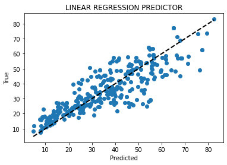

```python
print("Model\t\t\t RMSE \t\t R2")
plt.scatter(y_test, y_pred)
plt.plot([y_test.min(), y_test.max()], [y_test.min(), y_test.max()], 'k--', lw=2)
plt.xlabel("Predicted")
plt.ylabel("True")
plt.title("LINEAR REGRESSION PREDICTOR")
plt.show()
```

**Note**: The results of this algorithm are stored in dataframes model_scores and feature_importance. These results will be discussed in depth after all algorithms are run.

## **Random Forest:**

Back to Index

```python
from sklearn.ensemble import RandomForestRegressor

model = RandomForestRegressor()
model.fit(x_train, y_train)
```

```
RandomForestRegressor(bootstrap=True, ccp_alpha=0.0, criterion='mse',
                      max_depth=None, max_features='auto', max_leaf_nodes=None,
                      max_samples=None, min_impurity_decrease=0.0,
                      min_impurity_split=None, min_samples_leaf=1,
                      min_samples_split=2, min_weight_fraction_leaf=0.0,
                      n_estimators=100, n_jobs=None, oob_score=False,
                      random_state=None, verbose=0, warm_start=False)
```

```python
y_pred = model.predict(x_test)
```

```python
k = 20

kfold = KFold(n_splits=k, random_state = 42)
K_results = cross_val_score(model, X, y, cv=kfold)
accuracy = np.mean(abs(K_results))
```

```python
model_scores['RandomForest'] = [model.score(x_train, y_train), model.score(x_test, y_test)
                                      , accuracy, metrics.r2_score(y_test,y_pred), metrics.mean_squared_error(y_test,y_pred)]
```

```python
feature_importance['RandomForest'] = pd.DataFrame(model.feature_importances_, columns=['RandomForest'], index=x_train.columns)
```

```
Model			 RMSE 		 R2
```

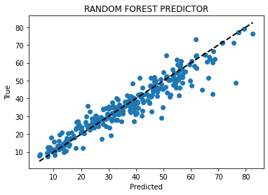

```python
print("Model\t\t\t RMSE \t\t R2")
plt.scatter(y_test, y_pred)
plt.plot([y_test.min(), y_test.max()], [y_test.min(), y_test.max()], 'k--', lw=2)
plt.xlabel("Predicted")
plt.ylabel("True")
plt.title("RANDOM FOREST PREDICTOR")
plt.show()
```

**Note**: The results of this algorithm are stored in dataframes model_scores and feature_importance. These results will be discussed in depth after all algorithms are run.

## **Gradient Boosting:**

Back to Index

```python
from sklearn.ensemble import GradientBoostingRegressor

model = GradientBoostingRegressor()
model.fit(x_train, y_train)
```

```
GradientBoostingRegressor(alpha=0.9, ccp_alpha=0.0, criterion='friedman_mse',
                          init=None, learning_rate=0.1, loss='ls', max_depth=3,
                          max_features=None, max_leaf_nodes=None,
                          min_impurity_decrease=0.0, min_impurity_split=None,
                          min_samples_leaf=1, min_samples_split=2,
                          min_weight_fraction_leaf=0.0, n_estimators=100,
                          n_iter_no_change=None, presort='deprecated',
                          random_state=None, subsample=1.0, tol=0.0001,
                          validation_fraction=0.1, verbose=0, warm_start=False)
```

```python
y_pred = model.predict(x_test)
```

```python
k = 20

kfold = KFold(n_splits=k, random_state = 42)
K_results = cross_val_score(model, X, y, cv=kfold)
accuracy = np.mean(abs(K_results))
```

```python
model_scores['GradientBoost'] = [model.score(x_train, y_train), model.score(x_test, y_test)
                                      , accuracy, metrics.r2_score(y_test,y_pred), metrics.mean_squared_error(y_test,y_pred)]
```

```python
feature_importance['GradientBoost'] = pd.DataFrame(model.feature_importances_, columns=['GradientBoost'], index=x_train.columns)
```

```
Model			 RMSE 		 R2
```

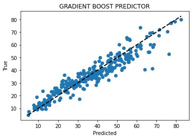

```python
print("Model\t\t\t RMSE \t\t R2")
plt.scatter(y_test, y_pred)
plt.plot([y_test.min(), y_test.max()], [y_test.min(), y_test.max()], 'k--', lw=2)
plt.xlabel("Predicted")
plt.ylabel("True")
plt.title("GRADIENT BOOST PREDICTOR")
plt.show()
```

**Note**: The results of this algorithm are stored in dataframes model_scores and feature_importance. These results will be discussed in depth after all algorithms are run.

## **Ada Boosting:**

Back to Index

```python
from sklearn.ensemble import AdaBoostRegressor

model = AdaBoostRegressor()
model.fit(x_train, y_train)
```

```
AdaBoostRegressor(base_estimator=None, learning_rate=1.0, loss='linear',
                  n_estimators=50, random_state=None)
```

```python
y_pred = model.predict(x_test)
```

```python
k = 20

kfold = KFold(n_splits=k, random_state = 42)
K_results = cross_val_score(model, X, y, cv=kfold)
accuracy = np.mean(abs(K_results))
```

```python
model_scores['AdaBoosting'] = [model.score(x_train, y_train), model.score(x_test, y_test)
                                      , accuracy, metrics.r2_score(y_test,y_pred), metrics.mean_squared_error(y_test,y_pred)]
```

```python
feature_importance['AdaBoosting'] = pd.DataFrame(model.feature_importances_, columns=['AdaBoosting'], index=x_train.columns)
```

```
Model			 RMSE 		 R2
```

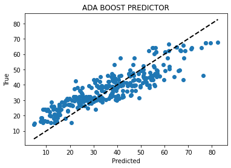

```python
print("Model\t\t\t RMSE \t\t R2")
plt.scatter(y_test, y_pred)
plt.plot([y_test.min(), y_test.max()], [y_test.min(), y_test.max()], 'k--', lw=2)
plt.xlabel("Predicted")
plt.ylabel("True")
plt.title("ADA BOOST PREDICTOR")
plt.show()
```

**Note**: The results of this algorithm are stored in dataframes model_scores and feature_importance. These results will be discussed in depth after all algorithms are run.

## **Bagging Regressor:**

Back to Index

```python
from sklearn.ensemble import BaggingRegressor

model = BaggingRegressor()
model.fit(x_train, y_train)
```

```
BaggingRegressor(base_estimator=None, bootstrap=True, bootstrap_features=False,
                 max_features=1.0, max_samples=1.0, n_estimators=10,
                 n_jobs=None, oob_score=False, random_state=None, verbose=0,
                 warm_start=False)
```

```python
y_pred = model.predict(x_test)
```

```python
k = 20

kfold = KFold(n_splits=k, random_state = 42)
K_results = cross_val_score(model, X, y, cv=kfold)
accuracy = np.mean(abs(K_results))
```

```python
model_scores['Bagging'] = [model.score(x_train, y_train), model.score(x_test, y_test)
                                      , accuracy, metrics.r2_score(y_test,y_pred), metrics.mean_squared_error(y_test,y_pred)]
```

```python
#print('Feature importances: \n', pd.DataFrame(model. , columns=['Importance'], index=x_train.columns))
#Couldn't get feature importance for bagging regressor. It seems that it's not available.
```

```
Model			 RMSE 		 R2
```

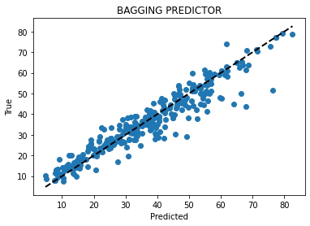

```python
print("Model\t\t\t RMSE \t\t R2")
plt.scatter(y_test, y_pred)
plt.plot([y_test.min(), y_test.max()], [y_test.min(), y_test.max()], 'k--', lw=2)
plt.xlabel("Predicted")
plt.ylabel("True")
plt.title("BAGGING PREDICTOR")
plt.show()
```

**Note**: The results of this algorithm are stored in dataframes model_scores and feature_importance. These results will be discussed in depth after all algorithms are run.

Back to Index

```python
from sklearn.svm import SVR

model = SVR(kernel='linear')
model.fit(x_train, y_train)
```

```
SVR(C=1.0, cache_size=200, coef0=0.0, degree=3, epsilon=0.1, gamma='scale',
    kernel='linear', max_iter=-1, shrinking=True, tol=0.001, verbose=False)
```

```python
y_pred = model.predict(x_test)
```

```python
k = 20

kfold = KFold(n_splits=k, random_state = 42)
K_results = cross_val_score(model, X, y, cv=kfold)
accuracy = np.mean(abs(K_results))
```

Computationally extremely heavy. Results are also poor.

```python
model_scores['SVC'] = [model.score(x_train, y_train), model.score(x_test, y_test)
                                      , accuracy, metrics.r2_score(y_test,y_pred), metrics.mean_squared_error(y_test,y_pred)]
```

```
Model			 RMSE 		 R2
```

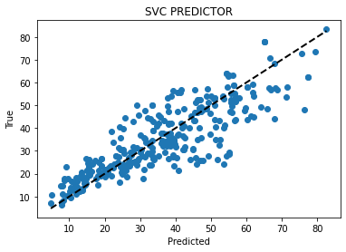

```python
print("Model\t\t\t RMSE \t\t R2")
plt.scatter(y_test, y_pred)
plt.plot([y_test.min(), y_test.max()], [y_test.min(), y_test.max()], 'k--', lw=2)
plt.xlabel("Predicted")
plt.ylabel("True")
plt.title("SVC PREDICTOR")
plt.show()
```

**Note**: The results of this algorithm are stored in dataframes model_scores and feature_importance. These results will be discussed in depth after all algorithms are run.

```python
#print('Feature importances: \n', pd.DataFrame(model.feature_importances_, columns=['Importance'], index=x_train.columns))
```

## **Decision Tree Regressor:**

Back to Index

```python
from sklearn.tree import DecisionTreeRegressor

model = DecisionTreeRegressor()
model.fit(x_train, y_train)
```

```
DecisionTreeRegressor(ccp_alpha=0.0, criterion='mse', max_depth=None,
                      max_features=None, max_leaf_nodes=None,
                      min_impurity_decrease=0.0, min_impurity_split=None,
                      min_samples_leaf=1, min_samples_split=2,
                      min_weight_fraction_leaf=0.0, presort='deprecated',
                      random_state=None, splitter='best')
```

```python
y_pred = model.predict(x_test)
```

```python
k = 20

kfold = KFold(n_splits=k, random_state = 42)
K_results = cross_val_score(model, X, y, cv=kfold)
accuracy = np.mean(abs(K_results))
```

```python
model_scores['Decision Tree'] = [model.score(x_train, y_train), model.score(x_test, y_test)
                                      , accuracy, metrics.r2_score(y_test,y_pred), metrics.mean_squared_error(y_test,y_pred)]
```

```
Model			 RMSE 		 R2
```

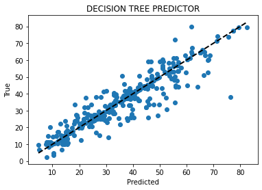

```python
print("Model\t\t\t RMSE \t\t R2")
plt.scatter(y_test, y_pred)
plt.plot([y_test.min(), y_test.max()], [y_test.min(), y_test.max()], 'k--', lw=2)
plt.xlabel("Predicted")
plt.ylabel("True")
plt.title("DECISION TREE PREDICTOR")
plt.show()
```

```python
model_scores # After re-including SVC details
```

|  | Linear Regression | Decision Tree | RandomForest | Bagging | AdaBoosting | GradientBoost | SVC |
| --- | --- | --- | --- | --- | --- | --- | --- |
| Training | 0.736390 | 0.994859 | 0.982360 | 0.979318 | 0.821456 | 0.948761 | 0.733994 |
| Testing | 0.714842 | 0.843143 | 0.904932 | 0.903237 | 0.763187 | 0.897852 | 0.708495 |
| KFold_Accuracy | 0.715005 | 0.867875 | 0.919173 | 0.903718 | 0.778889 | 0.905119 | 0.712533 |
| R2_Score | 0.714842 | 0.843143 | 0.904932 | 0.903237 | 0.763187 | 0.897852 | 0.708495 |
| Mean Squared Error | 82.992212 | 45.651536 | 27.668522 | 28.161849 | 68.922074 | 29.729062 | 84.839598 |

### **`Observations:`**

Back to Index

1. RandomForest, GradientBoost, and Bagging algorithms performed better in this case. It is worth to note that without making feature selection and hypertuning the model parameters, these algorithms achieved an acceptable testing score, KFold_Accuracy, and lowest Mean Squared Error. RandomForest performed the best in all aspects.
2. Linear Regression and SVC couldn't perform well. SVC was computationally expensive as well. **Note**: Linear Regression was used without polynomial features. It might be worth exploring if increasing value for hyper parameter **degree** improves the performance of the model.
3. In most cases, K-Fold validation accuracy was slightly better than testing scores. This is considered as a positive outcome here.
4. **Overfit Models**: A **Question** may arise as to which model can be considered overfit? Especially, in this case, can the models that are performing well (e.g. Random Forest / GradientBoost) be called overfit? While the answer to this question is very generic and subjective, following conclusions are made.

**Note**: While there is no rule on this, for the purpose of explanation, it is assumed that models having more than 10% difference in training and testing scores are overfit. It might also be worth noting that to avoid data leakage, K-Fold validation was performed, and in most models, K-Fold score was better than testing score.

**Final Conclusion**: Consider RandomForest and GradientBoost for further analysis / enhancements.

```python
feature_importance['Decision Tree'] = pd.DataFrame(model.feature_importances_, columns=['Decision Tree'], index=x_train.columns)
feature_importance
```

|  | Linear Regression | Decision Tree | RandomForest | Bagging | AdaBoosting | GradientBoost | SVC |
| --- | --- | --- | --- | --- | --- | --- | --- |
| cement | 0.104134 | 0.359236 | 0.327418 | NaN | 0.284026 | 0.315163 | NaN |
| slag | 0.070309 | 0.081493 | 0.069034 | NaN | 0.068875 | 0.071158 | NaN |
| ash | 0.039210 | 0.033495 | 0.018645 | NaN | 0.013681 | 0.011902 | NaN |
| water | -0.167283 | 0.125887 | 0.119841 | NaN | 0.189189 | 0.123162 | NaN |
| superplastic | 0.323883 | 0.018960 | 0.050283 | NaN | 0.037768 | 0.060336 | NaN |
| coarseagg | -0.004696 | 0.025197 | 0.027441 | NaN | 0.027071 | 0.010730 | NaN |
| fineagg | -0.006642 | 0.019194 | 0.041285 | NaN | 0.052889 | 0.034303 | NaN |
| age | 0.319810 | 0.336538 | 0.346052 | NaN | 0.326501 | 0.373245 | NaN |

### **`Observations:`**

Back to Index

**Note**: For simplicity, those attributes that contribute less than 0.03 across multiple models are considered as non-contributing attributes.

1. It appears that our the feature_importance dataframe coincides with our conclusion at the end of EDA: "Overall, cement, superplastic, water, and age contribute most significantly towards the strength".
2. However, it was surprising to see that **superplastic, which we recognized as an important contributor to the target variable during EDA, is not considered as an important feature by all the algorithms except linear regression.**
3. Referring to the **Note above**, ash and coarseagg contribute negligible to the models, specifically to RandomForest and GradientBoost, which will be considered for hyper parameter tuning.
4. Considering above point, ash will be dropped from the dataframe while coarseagg and fineagg will be added together to form a new field called totalagg.

## **Further Approach:**

Back to Index

1. Decide on the complexity of the model, should it be a simple linear model in terms of parameters or would a quadratic or higher degree.
2. Drop column ash
3. Create a new column called totalagg, and drop columns coarseagg and fineagg.
4. Hypertune RandomForest and GradientBoost based on the data above.
5. Choose final model.
6. Also check if Lasso and Ridge help here.

## **Final Feature Selection:**

Back to Index

```python
#Final Feature Selection

pdata['totalagg']=pdata['coarseagg']+pdata['fineagg']

#pdata['impurity']=pdata['ash']+pdata['slag']
# The above option was not explored as ash has no significance towards model. It didn't impact the final score.

X = pdata.drop(['strength','ash','coarseagg','fineagg'], axis=1)
y = pdata['strength']

x_train, x_test, y_train, y_test = train_test_split(X, y, test_size=0.3, random_state=1)
```

```python
#Check Lasso and Ridge
```

```python
from sklearn.linear_model import Ridge
from sklearn.linear_model import Lasso
```

```python
from sklearn.model_selection import GridSearchCV

n_samples, n_features = 10, 5
rng = np.random.RandomState(0)

parameters = {'alpha':[0.001, 0.01,0.02,0.03,0.04, 0.05, 0.06, 0.08, 1, 2, 3, 5, 8, 10, 20, 50, 100]}

# define the model/ estimator
LRR = Ridge()

# define the grid search
Ridge_reg= GridSearchCV(LRR, parameters, scoring='neg_mean_squared_error',cv=5)

#fit the grid search
Ridge_reg.fit(X,y)

# best estimator
print(Ridge_reg.best_estimator_)

# best model
best_LRR = Ridge_reg.best_estimator_
best_LRR.fit(X,y)
```

```
Ridge(alpha=100, copy_X=True, fit_intercept=True, max_iter=None,
      normalize=False, random_state=None, solver='auto', tol=0.001)
```

```
Ridge(alpha=100, copy_X=True, fit_intercept=True, max_iter=None,
      normalize=False, random_state=None, solver='auto', tol=0.001)
```

```python
#RIDGE SCORE
LRR = Ridge(alpha=1)
LRR.fit(x_train,y_train)
print ("Ridge model:", (LRR.coef_))
print("\n\n Linear Regression - Ridge Train Score: ",LRR.score(x_train, y_train))
print("\n\n Linear Regression - Ridge Test Score:  ",LRR.score(x_test, y_test))
```

```
Ridge model: [ 0.08284856  0.04490835 -0.22554889  0.38871653  0.3186826  -0.02425737]


 Linear Regression - Ridge Train Score:  0.7310140067835447


 Linear Regression - Ridge Test Score:   0.7026082741669217
```

```python
n_samples, n_features = 10, 5
rng = np.random.RandomState(0)

parameters = {'alpha':[0.001, 0.01,0.02,0.03,0.04, 0.05, 0.06, 0.08, 1, 2]}

# define the model/ estimator
LRL = Lasso()

# define the grid search
Lasso_reg= GridSearchCV(LRL, parameters, scoring='neg_mean_squared_error',cv=5)

#fit the grid search
Lasso_reg.fit(X,y)

# best estimator
print(Lasso_reg.best_estimator_)

# best model
best_LRL = Ridge_reg.best_estimator_
best_LRL.fit(X,y)
```

```
Lasso(alpha=0.001, copy_X=True, fit_intercept=True, max_iter=1000,
      normalize=False, positive=False, precompute=False, random_state=None,
      selection='cyclic', tol=0.0001, warm_start=False)
```

```
Ridge(alpha=100, copy_X=True, fit_intercept=True, max_iter=None,
      normalize=False, random_state=None, solver='auto', tol=0.001)
```

```python
# LASSO
LRL = Lasso(alpha=0.04)
LRL.fit(x_train,y_train)
print ("Lasso model:", (LRL.coef_))
print("\n\n Linear Regression - Lasso Train Score: ",LRL.score(x_train, y_train))
print("\n\n Linear Regression - Lasso Test Score:  ",LRL.score(x_test, y_test))
```

```
Lasso model: [ 0.08280789  0.04486914 -0.22608475  0.38596012  0.31865884 -0.02433336]


 Linear Regression - Lasso Train Score:  0.7310136755508754


 Linear Regression - Lasso Test Score:   0.7026550773517776
```

## **POLYNOMIAL WITH DEGREE 2**

Back to Index

```python
from sklearn import preprocessing

# ideally the training and test should be

X_scaled = preprocessing.scale(X)
X_scaled = pd.DataFrame(X_scaled, columns=X.columns)
```

```python
from sklearn.preprocessing import PolynomialFeatures
poly = PolynomialFeatures(degree = 2, interaction_only=True)
X_poly = poly.fit_transform(X_scaled)
X_train, X_test, y_train, y_test = train_test_split(X_poly, y, test_size=0.30, random_state=1)
X_train.shape
```

```
(721, 22)
```

```python
LR = LinearRegression()

LR.fit(X_train, y_train)
print(LR.coef_[0])
```

```
0.0
```

```python
ridge = Ridge(alpha=1)
ridge.fit(X_train,y_train)
print ("Ridge model:", (ridge.coef_))
```

```
Ridge model: [ 0.          8.8787356   4.82266028 -5.42537129  1.81418205  9.21149154
 -2.2468861   0.79361749  1.14076985  1.11696087 -0.50244832  1.13175401
  1.8699671   2.5352184   0.58946283  2.02687064  2.12469419 -0.87851337
 -1.27116368  0.21851562  1.5213131  -1.22851498]
```

```python
print("\n\n Linear Regression - Ridge Train Score degree 2: ",ridge.score(X_train, y_train))
print("\n\n Linear Regression - Ridge Test  Score: degree 2: ",ridge.score(X_test, y_test))
```

```
 Linear Regression - Ridge Train Score degree 2:  0.7662261749129335


 Linear Regression - Ridge Test  Score: degree 2:  0.7260328230038269
```

```python
lasso = Lasso(alpha=0.04)
lasso.fit(X_train,y_train)
print ("Lasso model:", (lasso.coef_))
```

```
Lasso model: [ 0.          8.73505374  4.71604151 -5.25883036  1.89705641  9.09797551
 -2.10159574  0.5596327   0.70147529  0.7768017  -0.28482315  0.70297562
  1.26085166  2.16512796  0.76016186  1.5447279   1.91534884 -0.65223337
 -1.34536715  0.2697474   1.30670817 -0.84645782]
```

```python
print("\n\n Linear Regression - Lasso Train Score degree 2: ",lasso.score(X_train, y_train))
print("\n\n Linear Regression - Lasso Train Score degree 2: ",lasso.score(X_test, y_test))
```

```
 Linear Regression - Lasso Train Score degree 2:  0.7655231583296092


 Linear Regression - Lasso Train Score degree 2:  0.7259932931019173
```

### **`Observations:`**

Back to Index

Performance increased slightly with degree = 2.

## **POLYNOMIAL WITH DEGREE 4:**

Back to Index

```python
from sklearn.preprocessing import PolynomialFeatures
poly1 = PolynomialFeatures(degree = 4, interaction_only=True)
X_poly = poly1.fit_transform(X_scaled)
X_train, X_test, y_train, y_test = train_test_split(X_poly, y, test_size=0.30, random_state=7)
X_train.shape
```

```
(721, 57)
```

```python
LR.fit(X_train, y_train)
print(LR.coef_[0])
```

```
1.679453288284711e-17
```

```python
ridge = Ridge(alpha=1)
ridge.fit(X_train,y_train)
print ("Ridge model:", (ridge.coef_))
```

```
Ridge model: [ 0.         10.75837012  3.42595327 -5.38372038  1.7034876  11.8990086
 -2.48599699 -1.46058467  1.78106273  2.26775098  1.58265312  1.61010434
 -0.87271467  0.03171875  2.25126745  0.77888153  0.82423048 -0.19822051
 -2.84277343  1.09363206  0.46399511 -0.31149587 -1.16680597 -2.42909491
 -0.09993001 -1.45872817  3.41300615  2.05067441  1.22630182 -0.73405504
 -0.72087861  1.58599747  0.10590911  0.9687727   0.28470591 -1.23247866
 -2.80968298  2.33110148  0.70078176  3.13805226  0.37039914 -1.96006648
 -1.68139812  0.10044346  0.12399168 -1.27531271 -1.24433579  2.0512146
 -0.30541529 -1.49361698 -0.68133129 -0.99967875 -1.37790219 -0.85509948
  0.08322248 -1.04935677 -1.18245428]
```

```python
print("\n\n Linear Regression - Ridge Train Score with Polinomial degree 4: ",ridge.score(X_train, y_train))
print("\n\n Linear Regression - Ridge Train Score with Polinomial degree 4: ",ridge.score(X_test, y_test))
```

```
 Linear Regression - Ridge Train Score with Polinomial degree 4:  0.8016292931428957


 Linear Regression - Ridge Train Score with Polinomial degree 4:  0.7515303797621462
```

```python
lasso = Lasso(alpha=0.04)
lasso.fit(X_train,y_train)
print ("Lasso model:", (lasso.coef_))
```

```
Lasso model: [ 0.         10.3505739   3.77822341 -5.10608641  1.6419791  10.61083784
 -2.38933757 -0.7939736   1.44511121  1.71416507  0.76507089  1.36845708
 -0.38785355  0.24422198  1.57884355  0.85105728  0.37908104 -0.54864791
 -2.64942466  1.20532728  0.28091024 -0.48305512 -0.48880309 -1.84079855
 -0.65231139 -1.0078029   2.92815607  1.58650352  0.95455539 -0.
 -0.7904083   0.56340944 -0.          0.          0.31480862 -0.50173588
 -2.48743503  1.41013567  0.6338777   2.62240733  0.53837975 -0.41393267
 -1.19960191  0.20730369  0.         -0.27649395 -1.12637984  0.99469923
  0.         -1.39957148 -0.09970202 -0.32929653 -0.37336582 -0.81411781
  0.         -0.         -0.70491612]
```

```python
print(lasso.score(X_train, y_train))
print(lasso.score(X_test, y_test))
```

```
0.7985965019766132
0.759482426556279
```

```
Model			 RMSE 		 R2
LASSO PREDICTOR 	 7.89 		0.76
```

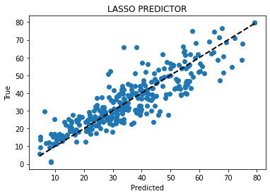

```python
y_pred_lasso = lasso.predict(X_test)
print("Model\t\t\t RMSE \t\t R2")
print("""LASSO PREDICTOR \t {:.2f} \t\t{:.2f}""".format( np.sqrt(metrics.mean_squared_error(y_test, y_pred_lasso)), metrics.r2_score(y_test, y_pred_lasso)))
plt.scatter(y_test, y_pred_lasso)
plt.plot([y_test.min(), y_test.max()], [y_test.min(), y_test.max()], 'k--', lw=2)
plt.xlabel("Predicted")
plt.ylabel("True")
plt.title("LASSO PREDICTOR")
plt.show()
```

### **`Observations:`**

Back to Index

Performance comparison --> Degree1 < Degree2 < Degree4. However, this performance is still comparatively lower than complex models like Random Forest Regressor and Gradient Boost Regressor.

## **Hypertune RandomForest and GradientBoost:**

Back to Index

```python
X = pdata.drop(['strength','ash','coarseagg','fineagg'], axis=1)
y = pdata['strength']

x_train, x_test, y_train, y_test = train_test_split(X, y, test_size=0.3, random_state=1)

#Use GridSearchCV and RandomizedSearchCV for further exploring hyper parameters
from sklearn.model_selection import GridSearchCV
from sklearn.model_selection import RandomizedSearchCV
from sklearn.datasets import load_digits
from scipy.stats import randint as sp_randint
```

```python
samples = 100  # number of random samples
```

### **Using RandomizedSearchCV:**

Back to Index

```python
param_dist = {"max_depth": [3, None],
              "max_features": sp_randint(1, 8),
              "min_samples_split": sp_randint(2, 6),
              "min_samples_leaf": sp_randint(1, 8),
              }

clf = GradientBoostingRegressor()

randomCV = RandomizedSearchCV(clf, param_distributions=param_dist, n_iter=samples) #default cv = 3

randomCV.fit(X,y)
```

```
RandomizedSearchCV(cv=None, error_score=nan,
                   estimator=GradientBoostingRegressor(alpha=0.9, ccp_alpha=0.0,
                                                       criterion='friedman_mse',
                                                       init=None,
                                                       learning_rate=0.1,
                                                       loss='ls', max_depth=3,
                                                       max_features=None,
                                                       max_leaf_nodes=None,
                                                       min_impurity_decrease=0.0,
                                                       min_impurity_split=None,
                                                       min_samples_leaf=1,
                                                       min_samples_split=2,
                                                       min_weight_fraction_leaf=0.0,
                                                       n_estimators=100...
                                        'max_features': <scipy.stats._distn_infrastructure.rv_frozen object at 0x7f4c65126518>,
                                        'min_samples_leaf': <scipy.stats._distn_infrastructure.rv_frozen object at 0x7f4c621eb588>,
                                        'min_samples_split': <scipy.stats._distn_infrastructure.rv_frozen object at 0x7f4c65126710>},
                   pre_dispatch='2*n_jobs', random_state=None, refit=True,
                   return_train_score=False, scoring=None, verbose=0)
```

```python
print(randomCV.best_params_)
```

```
{'max_depth': None, 'max_features': 3, 'min_samples_leaf': 6, 'min_samples_split': 4}
```

```python
model = GradientBoostingRegressor(max_depth= None, max_features= 3, min_samples_leaf= 6, min_samples_split= 4)
model.fit(x_train, y_train)

y_pred = model.predict(x_test)

print(model.score(x_train, y_train))

print(model.score(x_test, y_test))

print(metrics.r2_score(y_test,y_pred))

print(metrics.mean_squared_error(y_test,y_pred))

k = 20

kfold = KFold(n_splits=k, random_state = 42)
K_results = cross_val_score(model, X, y, cv=kfold)
accuracy = np.mean(abs(K_results))
print(accuracy)
```

```
0.992512847909588
0.9215384970225323
0.9215384970225323
22.835401225467518
0.9405558962914243
```

```python
new_model_scores = pd.DataFrame(index=['Training','Testing','KFold_Accuracy', 'R2_Score', 'Mean Squared Error'],
                   columns=['RandomSearch_GradientBoost','RandomSearch_RandomForest','GridSearch_GradientBoost','GridSearch_RandomForest'])
```

```python
new_model_scores['RandomSearch_GradientBoost'] = [model.score(x_train, y_train), model.score(x_test, y_test)
                                      , accuracy, metrics.r2_score(y_test,y_pred), metrics.mean_squared_error(y_test,y_pred)]
```

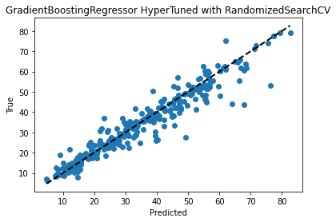

```python
plt.scatter(y_test, y_pred)
plt.plot([y_test.min(), y_test.max()], [y_test.min(), y_test.max()], 'k--', lw=2)
plt.xlabel("Predicted")
plt.ylabel("True")
plt.title("GradientBoostingRegressor HyperTuned with RandomizedSearchCV")
plt.show()
```

```python
param_dist = {"max_depth": [1,2,3,4,5,6,7,8,9,10,11,12,13,14,15,16,17,18,19,20, None],
              "max_features": sp_randint(1, 6),
              "min_samples_split": sp_randint(2, 11),
              "min_samples_leaf": sp_randint(1, 11),
              "bootstrap": [True, False]}

clf = RandomForestRegressor(n_estimators=500)

samples = 100  # number of random samples
randomCV = RandomizedSearchCV(clf, param_distributions=param_dist, n_iter=samples) #default cv = 3
```

```python
randomCV.fit(X,y)
```

```
RandomizedSearchCV(cv=None, error_score=nan,
                   estimator=RandomForestRegressor(bootstrap=True,
                                                   ccp_alpha=0.0,
                                                   criterion='mse',
                                                   max_depth=None,
                                                   max_features='auto',
                                                   max_leaf_nodes=None,
                                                   max_samples=None,
                                                   min_impurity_decrease=0.0,
                                                   min_impurity_split=None,
                                                   min_samples_leaf=1,
                                                   min_samples_split=2,
                                                   min_weight_fraction_leaf=0.0,
                                                   n_estimators=500,
                                                   n_jobs=None, oob_score=F...
                                        'max_features': <scipy.stats._distn_infrastructure.rv_frozen object at 0x7f4c61ca6588>,
                                        'min_samples_leaf': <scipy.stats._distn_infrastructure.rv_frozen object at 0x7f4c61c76470>,
                                        'min_samples_split': <scipy.stats._distn_infrastructure.rv_frozen object at 0x7f4c61c76208>},
                   pre_dispatch='2*n_jobs', random_state=None, refit=True,
                   return_train_score=False, scoring=None, verbose=0)
```

```python
print(randomCV.best_params_)
```

```
{'bootstrap': False, 'max_depth': 19, 'max_features': 3, 'min_samples_leaf': 1, 'min_samples_split': 6}
```

```python
model = RandomForestRegressor(bootstrap= False, max_depth= 19, max_features= 3, min_samples_leaf= 1, min_samples_split= 6, n_estimators=500)
model.fit(x_train, y_train)

y_pred = model.predict(x_test)

print(model.score(x_train, y_train))

print(model.score(x_test, y_test))

print(metrics.r2_score(y_test,y_pred))

print(metrics.mean_squared_error(y_test,y_pred))

k = 20

kfold = KFold(n_splits=k, random_state = 42)
K_results = cross_val_score(model, X, y, cv=kfold)
accuracy = np.mean(abs(K_results))
print(accuracy)
```

```
0.9879105558465292
0.9088400183224141
0.9088400183224141
26.53116086639011
0.9274916844432297
```

```python
new_model_scores['RandomSearch_RandomForest'] = [model.score(x_train, y_train), model.score(x_test, y_test)
                                      , accuracy, metrics.r2_score(y_test,y_pred), metrics.mean_squared_error(y_test,y_pred)]
```

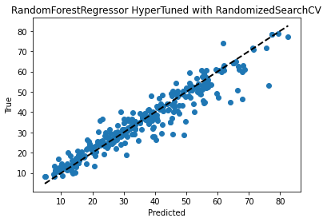

```python
plt.scatter(y_test, y_pred)
plt.plot([y_test.min(), y_test.max()], [y_test.min(), y_test.max()], 'k--', lw=2)
plt.xlabel("Predicted")
plt.ylabel("True")
plt.title("RandomForestRegressor HyperTuned with RandomizedSearchCV")
plt.show()
```

### **Using GridSearchCV**

Back to Index

```python
param_dist = {"max_depth": [3, None],
              "max_features": [1,2,3],
              "min_samples_split": [2,3],
              "min_samples_leaf": [5,6,7,8]
              }


clf = GradientBoostingRegressor()

grid = GridSearchCV( clf , param_grid = param_dist, cv = 5)

grid.fit( x_train, y_train)

print(" Best cross-validation accuracy: {:.2f}". format( grid.best_score_))
print(" Best parameters: ", grid.best_params_)
print(" Test set accuracy: {:.2f}". format( grid.score( x_test, y_test)))
```

```
 Best cross-validation accuracy: 0.91
 Best parameters:  {'max_depth': None, 'max_features': 3, 'min_samples_leaf': 7, 'min_samples_split': 3}
 Test set accuracy: 0.93
```

```python
model = GradientBoostingRegressor(max_depth= None, max_features= 3, min_samples_leaf= 7, min_samples_split= 3)
model.fit(x_train, y_train)

y_pred = model.predict(x_test)

print(model.score(x_train, y_train))

print(model.score(x_test, y_test))

print(metrics.r2_score(y_test,y_pred))

print(metrics.mean_squared_error(y_test,y_pred))

k = 20

kfold = KFold(n_splits=k, random_state = 42)
K_results = cross_val_score(model, X, y, cv=kfold)
accuracy = np.mean(abs(K_results))
print(accuracy)
```

```
0.9916620284074584
0.926781552110072
0.926781552110072
21.309464784948645
0.942562715819536
```

```python
new_model_scores['GridSearch_GradientBoost'] = [model.score(x_train, y_train), model.score(x_test, y_test)
                                      , accuracy, metrics.r2_score(y_test,y_pred), metrics.mean_squared_error(y_test,y_pred)]
```

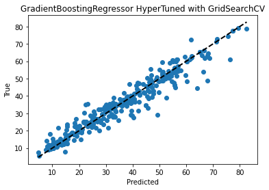

```python
plt.scatter(y_test, y_pred)
plt.plot([y_test.min(), y_test.max()], [y_test.min(), y_test.max()], 'k--', lw=2)
plt.xlabel("Predicted")
plt.ylabel("True")
plt.title("GradientBoostingRegressor HyperTuned with GridSearchCV")
plt.show()
```

```python
param_dist = {"max_depth": [ 6, 8, 10, None],
              "max_features": [1,3,4],
              "min_samples_split": [2,4],
              "min_samples_leaf": [1,3],
              "bootstrap": [True, False]}

clf = RandomForestRegressor()

grid = GridSearchCV( clf , param_grid = param_dist, cv = 5)

grid.fit( x_train, y_train)

print(" Best cross-validation accuracy: {:.2f}". format( grid.best_score_))
print(" Best parameters: ", grid.best_params_)
print(" Test set accuracy: {:.2f}". format( grid.score( x_test, y_test)))
```

```
 Best cross-validation accuracy: 0.89
 Best parameters:  {'bootstrap': False, 'max_depth': None, 'max_features': 3, 'min_samples_leaf': 1, 'min_samples_split': 2}
 Test set accuracy: 0.91
```

```python
model = RandomForestRegressor(bootstrap= True, max_depth= None, max_features= 3, min_samples_leaf= 1, min_samples_split= 2, n_estimators=500)
model.fit(x_train, y_train)

y_pred = model.predict(x_test)

print(model.score(x_train, y_train))

print(model.score(x_test, y_test))

print(metrics.r2_score(y_test,y_pred))

print(metrics.mean_squared_error(y_test,y_pred))


k = 20

kfold = KFold(n_splits=k, random_state = 42)
K_results = cross_val_score(model, X, y, cv=kfold)
accuracy = np.mean(abs(K_results))
print(accuracy)
```

```
0.983587169047206
0.9085082224489626
0.9085082224489627
26.62772659107923
0.9246152151965523
```

```python
new_model_scores['GridSearch_RandomForest'] = [model.score(x_train, y_train), model.score(x_test, y_test)
                                      , accuracy, metrics.r2_score(y_test,y_pred), metrics.mean_squared_error(y_test,y_pred)]
```

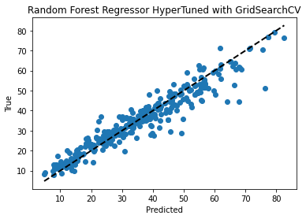

```python
plt.scatter(y_test, y_pred)
plt.plot([y_test.min(), y_test.max()], [y_test.min(), y_test.max()], 'k--', lw=2)
plt.xlabel("Predicted")
plt.ylabel("True")
plt.title("Random Forest Regressor HyperTuned with GridSearchCV")
plt.show()
```

```python
new_model_scores
```

|  | RandomSearch_GradientBoost | RandomSearch_RandomForest | GridSearch_GradientBoost | GridSearch_RandomForest |
| --- | --- | --- | --- | --- |
| Training | 0.992513 | 0.987911 | 0.991662 | 0.983587 |
| Testing | 0.921538 | 0.908840 | 0.926782 | 0.908508 |
| KFold_Accuracy | 0.940556 | 0.927492 | 0.942563 | 0.924615 |
| R2_Score | 0.921538 | 0.908840 | 0.926782 | 0.908508 |
| Mean Squared Error | 22.835401 | 26.531161 | 21.309465 | 26.627727 |

### **`Observations:`**

Back to Index

1. After Hyper Parameter Tuning it could be observed that Gradient Boost Regressor tuned using the parameters obtained by Grid Search CV provided the best performance. This model will be the model of choice.
2. It has a high value of R2_Squared, KFold_Accuracy and low value for Mean Squared Error
3. Grid Search CV is computationally intense. Therefore, unless we know a range of values for a parameter that might be best fit for a model, and that range is very small, it would be better to use Random Search CV.

# **`Deliverable – 5:`**

Back to Index

Write the significance of the R2 score from the business perspective. Explain the effect of an increase/decrease in the R2 score on the business model.

## **What is R-Squared?**

R-squared is a goodness-of-fit measure for linear regression models. This statistic indicates the percentage of the variance in the dependent variable that the independent variables explain collectively. R-squared measures the strength of the relationship between your model and the dependent variable on a convenient 0 – 100% scale. Thus, R-squared is the percentage of the dependent variable variation that a linear model explains.

**Why to use R-Squared?**

After fitting a linear regression model, one needs to determine how well the model fits the data. Does it do a good job of explaining changes in the dependent variable? This can be achieved using R-Squared. R-squared evaluates the scatter of the data points around the fitted regression line. For the same data set, higher R-squared values represent smaller differences between the observed data and the fitted values.

## **What is ideal value of R2-Squared?**

0% value of R2-Squared represents a model that does not explain any of the variation in the response variable around its mean. The mean of the dependent variable predicts the dependent variable as well as the regression model. 100% represents a model that explains all of the variation in the response variable around its mean. Usually, the larger the R2, the better the regression model fits your observations. There can be some limitations to this statement, that are not discussed here.

## **R-Squared And RMSE:**

It is generally accepted by statisticians that a regression model fits the data well if the differences between the observations and the predicted values are small and unbiased. Unbiased in this context means that the fitted values are not systematically too high or too low anywhere in the observation space. To understand the difference between predicted and actual values of a target variable, RMSE is used.

**RMSE**:

Root Mean Square Error (RMSE) is the standard deviation of the residuals (prediction errors). Residuals are a measure of how far from the regression line data points are; RMSE is a measure of how spread out these residuals are. In other words, it tells you how concentrated the data is around the line of best fit. RMSE close to zero and R-Square approaching 1 (100%) are indicative of high accuracy between observed and predicted values.

In short, higher is the R2-Squared value, lower is the RMSE. Higher is the R2-Squared value, the model has better predictability (With some exceptions, e.g. an overfit model).

```python
model_scores
```

|  | Linear Regression | Decision Tree | RandomForest | Bagging | AdaBoosting | GradientBoost | SVC |
| --- | --- | --- | --- | --- | --- | --- | --- |
| Training | 0.736390 | 0.994859 | 0.982360 | 0.979318 | 0.821456 | 0.948761 | 0.733994 |
| Testing | 0.714842 | 0.843143 | 0.904932 | 0.903237 | 0.763187 | 0.897852 | 0.708495 |
| KFold_Accuracy | 0.715005 | 0.867875 | 0.919173 | 0.903718 | 0.778889 | 0.905119 | 0.712533 |
| R2_Score | 0.714842 | 0.843143 | 0.904932 | 0.903237 | 0.763187 | 0.897852 | 0.708495 |
| Mean Squared Error | 82.992212 | 45.651536 | 27.668522 | 28.161849 | 68.922074 | 29.729062 | 84.839598 |

```python
new_model_scores
```

|  | RandomSearch_GradientBoost | RandomSearch_RandomForest | GridSearch_GradientBoost | GridSearch_RandomForest |
| --- | --- | --- | --- | --- |
| Training | 0.992513 | 0.987911 | 0.991662 | 0.983587 |
| Testing | 0.921538 | 0.908840 | 0.926782 | 0.908508 |
| KFold_Accuracy | 0.940556 | 0.927492 | 0.942563 | 0.924615 |
| R2_Score | 0.921538 | 0.908840 | 0.926782 | 0.908508 |
| Mean Squared Error | 22.835401 | 26.531161 | 21.309465 | 26.627727 |

In the above model_scores dataframe (obtained before performing hypertuining and feature selection) and new_model_scores (obtained after performing hypertuning and feature selection), it can be observed that:

1. R2-Squared for most models is almost similar to their testing scores.
2. Higher is the R2-Squared value, lower is the mean squared error. (RMSE = square root of this mean squared error).
3. The models that we chose for hypertuning (RandomForestRegressor and GradientBoostRegressor) had high value of R2-Square and lower value of RMSE.

# **`Deliverable – 6:`**

Back to Index

Write down the inference about the data analysis and write the recommendations which can be beneficial to the business based on the whole analysis. Also, write the reason for your recommendation. **(8 Marks)**

## Conclusion:

Based on the analysis of data, and at the end of the project, following are key takeaways and recommendations.

**Note**: Following is only the summary of the recommendation and observations throughout the project. Please refer to the section **"Observations"** at different points in this project for an in-depth analysis behind these recommendations.

1. Strength increases as the amount of cement increases in the mixture.
2. Strength increases with age, this not the case always (Since there are outliers in the data), but can be up to an extent.
3. Mixtures with less age requires more cement for higher strength.
4. The older the cement is the more water it requires. It might be worth to water the concerete as it gets older (e.g. exposure to rain).
5. Concrete strength increases when less water is used in preparing it.
6. Strength decreases as ash increases, therefore as ash can be considered as an impurity to concrete.
7. Initial analysis suggested that strength increases with an increase in superplasticizers. However, it was contradicted by models. This area might be further explored (from the perspective of ML).
8. The data, in and itself, was good enough to create a reliable model. Unnecessary imputations may cause an issue with integrity, and therefore, the overall quality of data.
9. **Complex models like Random Forest Regressor and Gradient Boost Regressor performed well without any major changes to data / hyper parameters. Therefore, it might be worth noting that whenever building model, best practice is to start with the defaults and then try to improve the model / data**

# **`Deliverable – 7:`**

Back to Index

```python
#The final model chosen here is:

model = GradientBoostingRegressor(max_depth= None, max_features= 3, min_samples_leaf= 7, min_samples_split= 3)
```

```python
new_model_scores
```

|  | RandomSearch_GradientBoost | RandomSearch_RandomForest | GridSearch_GradientBoost | GridSearch_RandomForest |
| --- | --- | --- | --- | --- |
| Training | 0.992513 | 0.987911 | 0.991662 | 0.983587 |
| Testing | 0.921538 | 0.908840 | 0.926782 | 0.908508 |
| KFold_Accuracy | 0.940556 | 0.927492 | 0.942563 | 0.924615 |
| R2_Score | 0.921538 | 0.908840 | 0.926782 | 0.908508 |
| Mean Squared Error | 22.835401 | 26.531161 | 21.309465 | 26.627727 |

All the models that we chose and hypertuned performed well, but the model of our choice performed the best in terms of testing, kfold_accuracy, R2_Square and mean squared error. The predicted values of target variable are closely located to the best fit line.